# B-cos Explainable AI on Iris Dataset

This notebook demonstrates explainable AI using B-cos (B-cosine) networks on the Iris dataset. B-cos networks provide inherent interpretability through their cosine similarity-based computations, making them ideal for understanding model decisions.

1. Introduction and Setup
2. Data Loading and EDA
3. Data Preprocessing
4. B-cos Model Implementation
5. Standard Model for Comparison
6. Training Pipeline
7. Model Evaluation
8. Explainability Analysis
9. Advanced Visualizations
10. Interpretability Metrics
11. Comprehensive Comparison
12. Conclusions and Insights

## 1. Introduction and Setup

In this section, we'll import all necessary libraries and set up the environment for reproducible results.

```python
# Import necessary libraries
import numpy as np
import pandas as pd
import matplotlib.pyplot as plt
import seaborn as sns
from sklearn.datasets import load_iris
from sklearn.model_selection import train_test_split
from sklearn.preprocessing import StandardScaler
from sklearn.metrics import accuracy_score, classification_report, confusion_matrix, roc_auc_score
import torch
import torch.nn as nn
import torch.optim as optim
from torch.utils.data import DataLoader, TensorDataset
import plotly.express as px
import plotly.graph_objects as go
from plotly.subplots import make_subplots
import warnings
warnings.filterwarnings('ignore')

# Set random seeds for reproducibility
np.random.seed(42)
torch.manual_seed(42)
if torch.cuda.is_available():
    torch.cuda.manual_seed(42)

# Configure matplotlib and seaborn for high-quality plots
plt.style.use('seaborn-v0_8')
sns.set_palette("husl")
plt.rcParams['figure.figsize'] = (12, 8)
plt.rcParams['font.size'] = 12

print("Libraries imported successfully!")
print(f"PyTorch version: {torch.__version__}")
print(f"NumPy version: {np.__version__}")
print(f"Pandas version: {pd.__version__}")
```

```
Libraries imported successfully!
PyTorch version: 1.11.0+cpu
NumPy version: 1.26.4
Pandas version: 2.0.3
```

## 2. Data Loading and EDA

Let's load the Iris dataset and perform comprehensive exploratory data analysis to understand the data structure and relationships.

```python
# Load the Iris dataset
iris = load_iris()
X = pd.DataFrame(iris.data, columns=iris.feature_names)
y = pd.DataFrame(iris.target, columns=['species'])

# Create species names mapping
species_names = {0: 'setosa', 1: 'versicolor', 2: 'virginica'}
y['species_name'] = y['species'].map(species_names)

# Combine features and target for analysis
data = pd.concat([X, y], axis=1)

print("Dataset shape:", data.shape)
print("\nFirst few rows:")
print(data.head())

print("\nDataset info:")
print(data.info())

print("\nStatistical summary:")
print(data.describe())
```

```
Dataset shape: (150, 6)

First few rows:
   sepal length (cm)  sepal width (cm)  petal length (cm)  petal width (cm)  \
0                5.1               3.5                1.4               0.2
1                4.9               3.0                1.4               0.2
2                4.7               3.2                1.3               0.2
3                4.6               3.1                1.5               0.2
4                5.0               3.6                1.4               0.2

   species species_name
0        0       setosa
1        0       setosa
2        0       setosa
3        0       setosa
4        0       setosa

Dataset info:
<class 'pandas.core.frame.DataFrame'>
RangeIndex: 150 entries, 0 to 149
Data columns (total 6 columns):
 #   Column             Non-Null Count  Dtype
---  ------             --------------  -----
 0   sepal length (cm)  150 non-null    float64
 1   sepal width (cm)   150 non-null    float64
 2   petal length (cm)  150 non-null    float64
 3   petal width (cm)   150 non-null    float64
 4   species            150 non-null    int32
 5   species_name       150 non-null    object
dtypes: float64(4), int32(1), object(1)
memory usage: 6.6+ KB
None

Statistical summary:
       sepal length (cm)  sepal width (cm)  petal length (cm)  \
count         150.000000        150.000000         150.000000
mean            5.843333          3.057333           3.758000
std             0.828066          0.435866           1.765298
min             4.300000          2.000000           1.000000
25%             5.100000          2.800000           1.600000
50%             5.800000          3.000000           4.350000
75%             6.400000          3.300000           5.100000
max             7.900000          4.400000           6.900000

       petal width (cm)     species
count        150.000000  150.000000
mean           1.199333    1.000000
std            0.762238    0.819232
min            0.100000    0.000000
25%            0.300000    0.000000
50%            1.300000    1.000000
75%            1.800000    2.000000
max            2.500000    2.000000
```

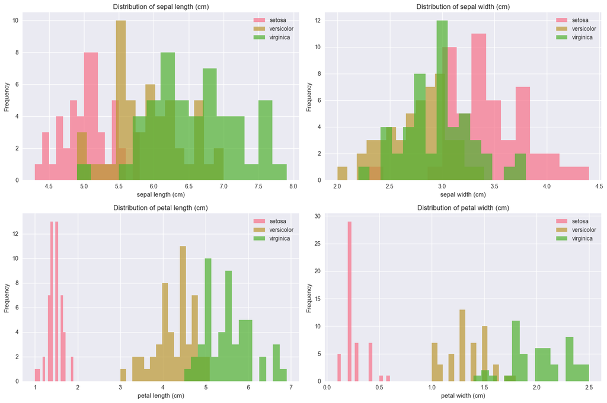

```python
# Distribution plots for each feature
fig, axes = plt.subplots(2, 2, figsize=(15, 10))
axes = axes.ravel()

for i, feature in enumerate(iris.feature_names):
    axes[i].hist(data[data['species'] == 0][feature], alpha=0.7, label='setosa', bins=15)
    axes[i].hist(data[data['species'] == 1][feature], alpha=0.7, label='versicolor', bins=15)
    axes[i].hist(data[data['species'] == 2][feature], alpha=0.7, label='virginica', bins=15)
    axes[i].set_title(f'Distribution of {feature}')
    axes[i].set_xlabel(feature)
    axes[i].set_ylabel('Frequency')
    axes[i].legend()

plt.tight_layout()
plt.show()
```

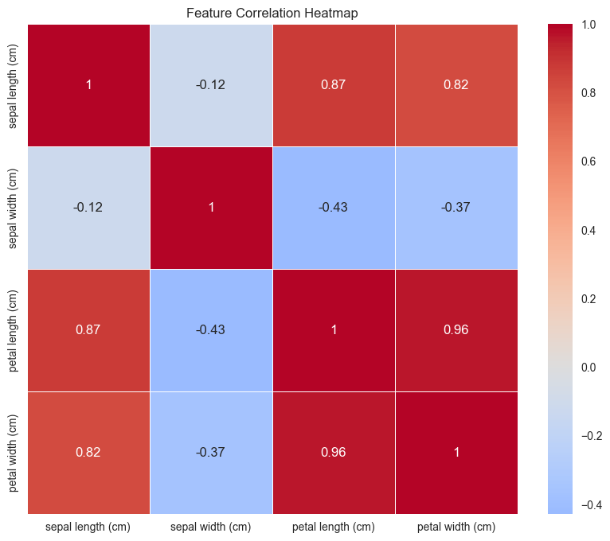

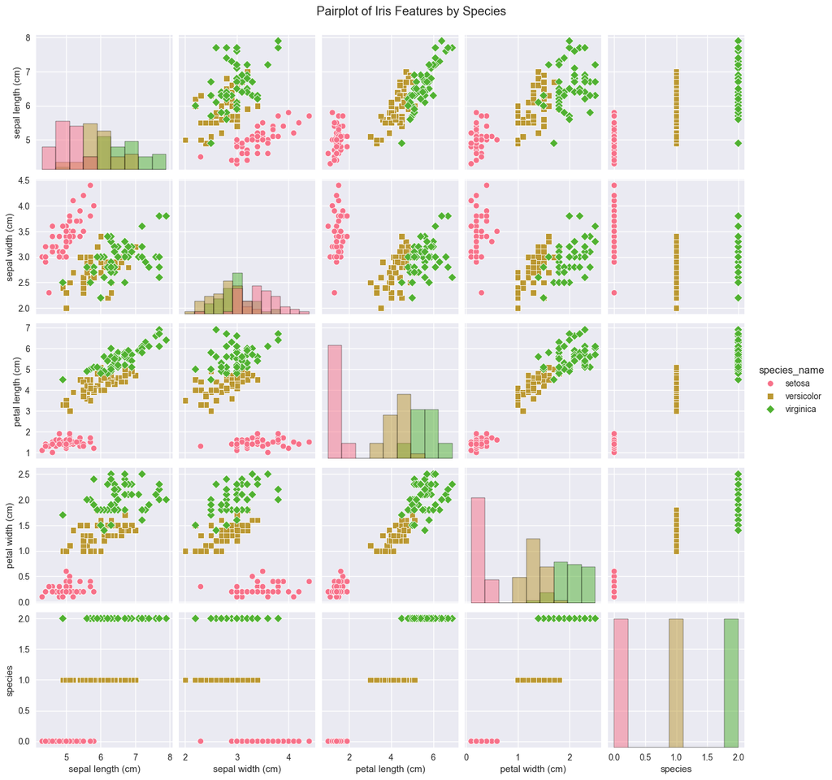

```python
# Correlation heatmap
plt.figure(figsize=(10, 8))
correlation_matrix = data[iris.feature_names].corr()
sns.heatmap(correlation_matrix, annot=True, cmap='coolwarm', center=0,
            square=True, linewidths=0.5)
plt.title('Feature Correlation Heatmap')
plt.show()

# Pairplot with species coloring
plt.figure(figsize=(12, 10))
sns.pairplot(data, hue='species_name', diag_kind='hist', markers=['o', 's', 'D'])
plt.suptitle('Pairplot of Iris Features by Species', y=1.02)
plt.show()
```

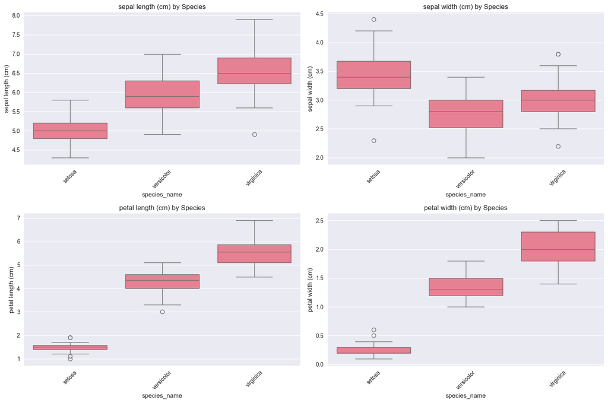

```python
# 3D scatter plot
fig = px.scatter_3d(data, x='sepal length (cm)', y='sepal width (cm)', z='petal length (cm)',
                    color='species_name', title='3D Scatter Plot of Iris Features',
                    labels={'sepal length (cm)': 'Sepal Length',
                           'sepal width (cm)': 'Sepal Width',
                           'petal length (cm)': 'Petal Length'})
fig.update_layout(scene=dict(xaxis_title='Sepal Length (cm)',
                            yaxis_title='Sepal Width (cm)',
                            zaxis_title='Petal Length (cm)'))
fig.show()

# Box plots for each feature
plt.figure(figsize=(15, 10))
for i, feature in enumerate(iris.feature_names):
    plt.subplot(2, 2, i+1)
    sns.boxplot(data=data, x='species_name', y=feature)
    plt.title(f'{feature} by Species')
    plt.xticks(rotation=45)

plt.tight_layout()
plt.show()
```